# Основы интерфейса взаимодействия пользователя с системой Unix на уровне командной строки

Лабораторная работа №6

Никифоров Захар Сергеевич

1032253520@rudn.ru

Российский университет дружбы народов

2026-03-19

# Вводная часть

## Актуальность

- Большинство серверов управляются через командную строку
- Все больше и больше делается на ОС семейства UNIX/Linux
- Командная строка является базовым инструментом

## Объект и предмет исследования

- Объект исследования: текстовый интерфейс взаимодействия с системой
- Предмет исследования: командная строка

## Цели и задачи

Цель: Приобретение практических навыков взаимодействия пользователя с системой по- средством командной строки.

Задачи: 1. Освоить базовые команды командной строки 2. Научится перемещаться в файловой системе 3. Освоить удаление файлов и каталогов 4. Изучить использование справочной системы 5. Ознакомиться с историей команд

## Материалы и методы

- Оборудование: ПК с ОС на базе Linux или ВМ на нем с такой системой
- ПО: Fedora WorkStation
- Методы: Знакомство согласно руководству, опыты, изучение документации.

# Выполнение лабораторной работы

## **Имя домашнего каталога**

zahnickiforov — имя моего домашнего каталога.

## **Просмотр каталогов**

### **ls**

Переходим в каталог **tmp** с помощью команды **cd** и смотрим содержимое с помощью команды **ls**

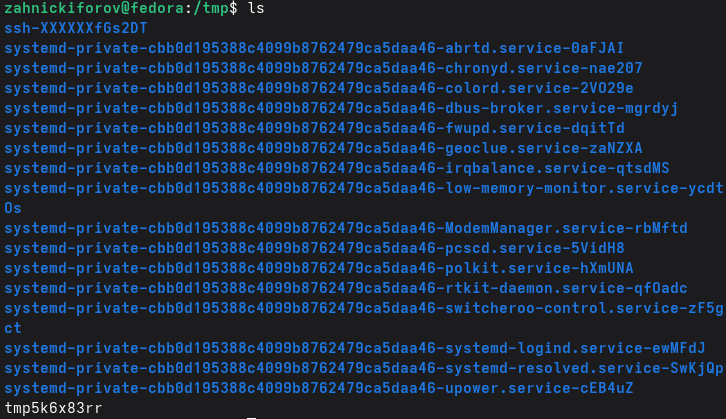

Рисунок 2: Содержимое tmp

Попробуем добавить опции.

### **ls -a**

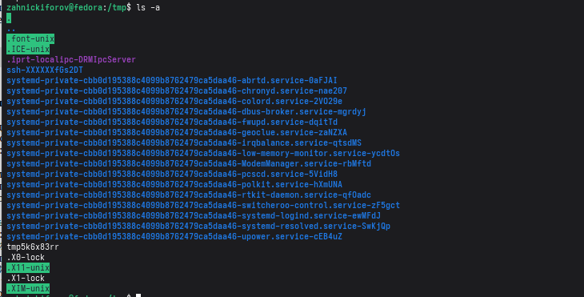

Рисунок 3: Содержимое tmp + его скрытые файлы

### **ls -l**

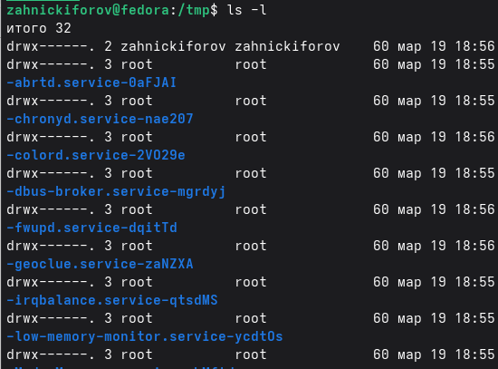

Рисунок 4: Подробное содержимое tmp

### **ls -alF**

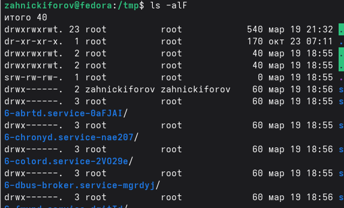

Рисунок 5: Подробное содержимое tmp + его скрытые файлы

## **Проверка наличия cron в /var/spool**

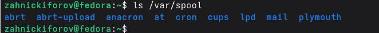

Рисунок 6: Содержимое /var/spool

## **Вывод содержимого домашнего каталога**

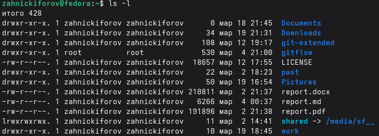

Рисунок 7: Содержимое домашнего каталога

## **Создание и удаление каталогов**

### **Создадим каталог newdir, а в нем morefun**

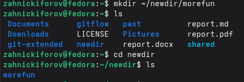

Рисунок 8: Создание каталогов

### **Создание каталогов memos, letter, misk**

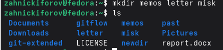

Рисунок 9: Создание каталогов 2

### **Удаление с помощью rm -r**

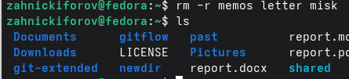

Рисунок 10: Удаление каталогов

### **Удаление newdir с помощью rm**

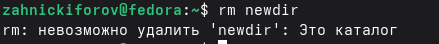

Рисунок 11: Попытка удаления каталога

## **Команда man**

### **ls -R**

С помощью команды **man** найдем опцию для команды **ls**, чтобы рекурсивно посмотреть содержимое каталога

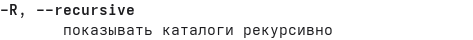

Рисунок 12: Опция для ls

### **ls -lt**

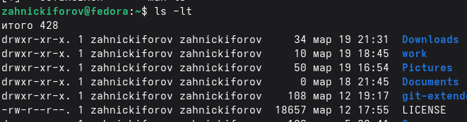

Рисунок 13: ls -lt

## **Основные опции команд**

### **pwd**

- не имеет обязательных аргументов и просто показывает, где ты в системе

### **mkdir**

‘-p’ — создает вложенные каталоги ‘-m’ — задает права доступа

### **rmdir**

- удаляет пустые каталоги и только пустые. Если есть файлы, то не сработает

### **rm**

‘-r’ — рекурсивное удаление каталогов с содержимым ‘-i’ — запрос подтверждения перед удалением ‘-f’ — принудительное удаление без запросов

## **Команда history**

### **Выполнение команд по номеру**

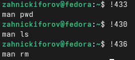

Рисунок 15: Выполнение команд по номеру исполнения

# Выводы

- Были приобретены практические навыки взаимодействия пользователя с системой посредством командной строки.